# Political psychology

Andy Wills, Yaniv Hanoch

## Before you start…

Before starting this exercise, you should have completed **all** the Absolute Beginners’, Part 1 worksheets. If not, take a look at those exercises before continuing. Each section below also indicates which of the earlier worksheets are relevant.

## Getting the data into R

**Relevant worksheet:** Intro to RStudio

You’ll need to complete the Psych:EL exercise to get the CSV files containing your data, and data for your group. Open an RStudio project for this analysis, within that create a script file for this analysis, and upload the CSV files to the project.

## Exploring your data

### Load

**Relevant worksheet:** Exploring data

Load the *tidyverse* package, and load your data.

```r
# Policital psychology
# Load tidyverse
library(tidyverse)
# Load data
brex <- read_csv("brexit.csv")
```

### Inspect

Look at the data by clicking on it in the *Environment* tab in RStudio. Each row is one person’s rating for one question. Here’s what each of the columns in the data set contain:

| Column | Description | Values |
| --- | --- | --- |
| UnRowID | Unique Row ID: you can ignore this. |  |
| SRN | Your Student Reference Number |  |
| cond | How would you vote in a Brexit referendum? | “leave”, “remain” |
| type | Which questionnaire is this a response for? | “auth” = Authoritarian Personality Scale, “dom” = Social Dominance Orientation questionnaire |
| qu | This number uniquely identifies the question that was asked | 1 - 21 |
| rating | The rating given in response to this question | 1 - 7, higher numbers = more authoritarian / higher social dominance orientation |

### Calculating your own personality scores

**Relevant worksheets:** Group Differences

How highly did you score on each of the two questionnaires (Authoritarian Personality Scale, Social Dominance Orientation questionniare)?

To look at this, you have to calculate your average (mean) rating for each questionnaire. To do this, use the `group_by` and `summarise` commands you learned in the *Group Differences* worksheet.

```r
# Group data by 'type', display mean of 'rating'
brex %>% group_by(type) %>% summarise(mean(rating))
```

```
# A tibble: 2 × 2
  type  `mean(rating)`
  <chr>          <dbl>
1 auth            3.95
2 dom             3.25
```

As before, you can safely ignore the “ungrouping” message that you receive.

**NOTE:** Your output should look similar to that shown above, but the numbers will be different.

## Exploring everyone’s data

### Load data

**Relevant worksheet:** Exploring data

Load the data.

```r
# Load everyone's data into 'brex.all'
brex.all <- read_csv("brexit-all.csv")
```

### Inspect

Look at the data by clicking on it in the *Environment* tab in RStudio. You’ll see it has the same columns as the the other data file, it just has a lot more rows (because it contains a lot of participants).

### Do ‘leavers’ score higher on an Authoritarian Personality scale?

**Relevant worksheet:** Group Differences

It’ll take a few steps to answer this question:

#### 1. Filter

First, we first need to filter the data so it only contains the responses to the Authoritarian Personality questionnaire (and not the Social Dominance Orientation questionnaire). We do this using the `filter` command we covered in the *Group Differences* worksheet:

```r
# Filter 'auth' questionnaire into 'auth' data frame
auth <- brex.all %>% filter(type == "auth")
```

#### 2. Summarise

Next, we summarize this large amount of data, so we have just one overall score on the questionnaire for each person. We use the `summarise` command to do this, which we learned in the *Exploring Data* worksheet. We also need to use the `group_by` command (covered in *Group Differences*), so that we get one score for each person (using the column `SRN`). We also add the column `cond` to the `group_by` command, so that our summarized data still contains information about which condition each person was in (i.e. whether they voted *leave* or *remain*):

```r
# Group 'auth' by 'cond' and 'SRN'; calculate mean of 'rating'; place results in 'auth.sum'
auth.sum <- auth %>% group_by(cond, SRN) %>% summarise(rating = mean(rating))
```

If you look at `auth.sum` by clicking on it in the *Environment* tab in RStudio, you’ll see we now have just one row for each person.

#### 3. Plot

Now we can look at the distribution of scores on this personality scale for *leavers* and *remainers*. A *density plot* is a good choice for this (you learned to produce these in the *Group Differences* worksheet). Here, we’re going to make a density plot of the data in column `rating` of the `auth.sum` data frame. We use the `cond` column to set the colour of the density plot, leaving us with two distributions – one for *leavers* and one for *remainers* :

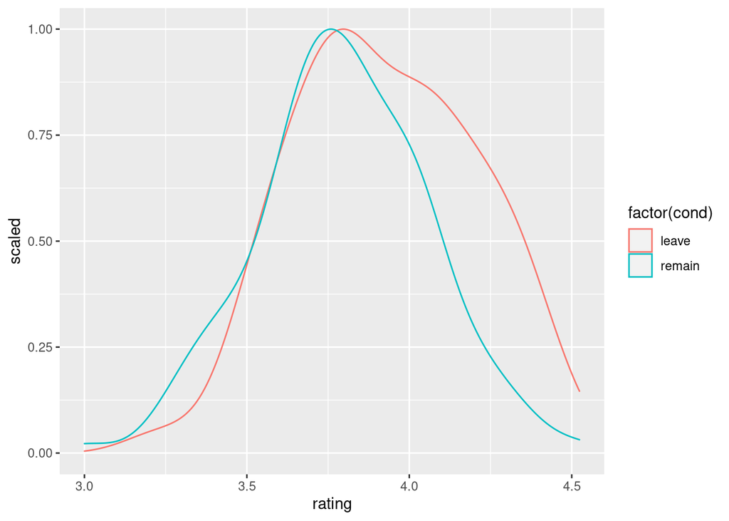

```r
# Display density plot of 'rating', by 'cond'
auth.sum %>% ggplot(aes(rating, colour = factor(cond))) + geom_density(aes(y = ..scaled..))
```

Your plot should look something like this, although the coloured lines will be somewhat different. In this example plot, the *leavers* seem to score a bit higher overall than the *remainers*, although the two sets of scores also overlap a lot. *What happens in your plot?*

#### 4. Effect size

As we covered in the *Group Differences* worksheet, an effect size is the difference between the mean scores of the two groups, divided by the *standard deviation* (a measure of how much the scores vary around those means). Here, we’re going to calculate the effect size for this personality difference in *leavers* and *remainers*. We use the `cohen.d` command to do this, as covered in the *Group Differences* worksheet.

```r
# Load package that calculates effect sizes
library(effsize)
# Calculate Cohen's d for effect of 'cond' on 'rating'
cohen.d(auth.sum$rating ~ auth.sum$cond)
```

```
Cohen's d

d estimate: 0.4810782 (small)
95 percent confidence interval:
    lower     upper
0.1731142 0.7890421
```

If the example above, our effect size (*Cohen’s d*) is around 0.48, which is normally described as being between a *small* and a *medium* effect (see *Group Differences* for the meaning of *small* in this context, it does not imply “unimportant”).

**Enter your Cohen’s d value into PsycEL.** Your number will likely be somewhat different to the one in the above example.

### 5. Evidence

**Relevant worksheet:** Evidence

How good is the evidence that this is a real result, and not just some kind of fluke we can put down to chance? The best way to answer this question is to calculate a Bayes Factor, as was covered in the *Evidence* worksheet. In this case, the data frame is `auth.sum`, with the column `rating` containing the questionnaire scores, and the column `cond` containing information about the *condition* (i.e. whether each person voted *leave* or *remain*):

```r
# Load BayesFactor package
library(BayesFactor, quietly = TRUE)
# Calculate Bayesian t-test for effect of 'cond' on 'rating'.
ttestBF(formula = rating ~ cond, data = data.frame(auth.sum))
```

```
Bayes factor analysis
--------------
[1] Alt., r=0.707 : 14.07864 ±0%

Against denominator:
  Null, mu1-mu2 = 0
---
Bayes factor type: BFindepSample, JZS
```

In this example, The Bayes Factor is about 14, meaning it’s about 14 times as likely that there is a difference, than there isn’t.

**Enter your exact Bayes Factor into PsycEL.** (The Bayes Factor for your data will likely be a bit different to the one above).

### Do ‘leavers’ score higher on a Social Dominance Orientation scale?

In this final part of the exercise, the task is to produce a density plot, calculate the effect size, and calculate the Bayes Factor, for the *other* questionnaire … the Social Dominance questionnaire. Go through the steps above, changing the code so you’re doing the same analyses on this other questionnaire. To get you started, here’s Step 1:

```r
# Filter 'dom' questionnaire into 'dom' data frame
dom <- brex.all %>% filter(type == "dom")
```

**Enter your effect size, and Bayes Factor, for the Social Dominance Orientation scale, into PsycEL.**

This material is distributed under a [Creative Commons](https://creativecommons.org/) licence. CC-BY-SA 4.0.